# PeMS traffic flow and reported events | 2026-06-16

Twenty-four hourly frames on 2026-06-16, with 4,435 Los Angeles Area road links, 2,203 San Francisco Bay Area road links, and 1,019 CHP reported event starts: 700 in the Los Angeles selection and 319 in D04.

## Interactive map

LayersRoadsEventsBasemapRoad casing

Region

Event category

Time

[interactive chart not shown]

Mean of finite road values

[interactive chart not shown]

Events by reported start interval

Statistics cover the selected records, including locations outside the current view. Times and units retain their supplied meanings.

## Summary

### All records

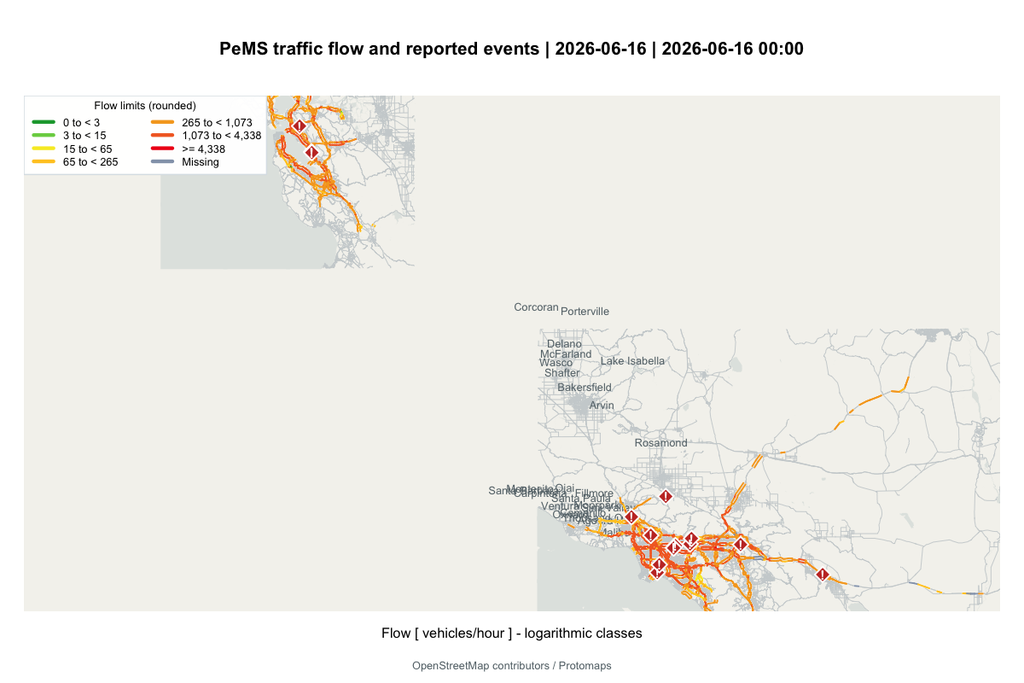

#### Flow trend

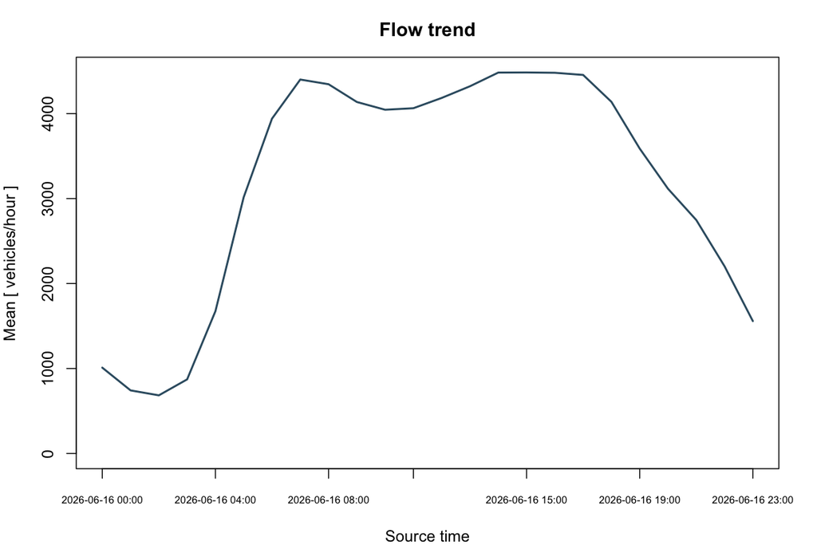

#### Event trend

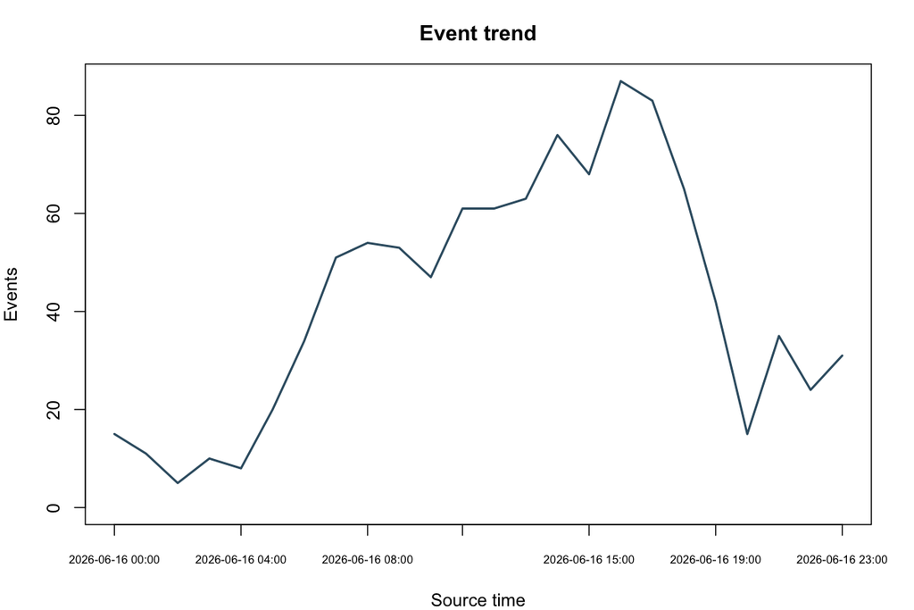

Dataset

| frames | roads | events | first_time |
| --- | --- | --- | --- |
| 24 | 6,638 | 1,019 | 2026-06-16 00:00 |

Displayed interval

| frame | time | roads | events |
| --- | --- | --- | --- |
| 1 | 2026-06-16 00:00 | 6,638 | 15 |

Flow availability

| available | missing | zero |
| --- | --- | --- |
| 6,582 | 56 | 1 |

Flow distribution

| minimum | median | mean | p95 | maximum |
| --- | --- | --- | --- | --- |
| 0 | 969.25 | 1,010 | 2,032 | 6,936 |

Statistics cover all input records. Means and distributions use finite road values; missing observations are counted separately. Reported events are counted by start interval. Road-value sums are not interpreted as distinct vehicle counts.

## Preparation

Los Angeles values are the selected hourly rows from flow_2026_06.binz. Available active positions are averaged within stations, then available endpoint-station values are averaged for each display link. An unavailable pair is NA; zero remains observed.

D04 records come from d04_text_station_5min_2026_06_16.txt.gz and the matching cleaned day. Station identities and coordinates use the 2026-04-08 metadata snapshot. Each of the 2,288 matched mainline stations has 288 five-minute records. Twelve five-minute counts are summed per hour, and available endpoint totals are averaged for each link.

Polyline vertices follow travel direction. Station order is increasing absolute postmile for north/east travel and decreasing for south/west travel, with the Caltrans backward-route exceptions. Endpoint station, index and postmile fields follow this order. Link values remain endpoint means.

The two regions share the same road_id, time and flow schema. Their region labels identify geographic groups. No display styles are stored with the input records.

Offline context contains longitude/latitude geometry, optional Point captions in properties.label and a supplied attribution string.

CHP event IDs, reported times, coordinates, categories and descriptions retain their supplied values. The event and road frame clocks coincide. Events belong to the half-open hourly interval containing the reported start. The supplied D07, D08 and D12 event selection has region Los Angeles Area before the common constructor is called.

D04 event summaries are selected by source district 04 and reported date 2026-06-16 from the monthly CHP archive. IDs, reported timestamps and coordinates retain source values. Original event types use the existing CHP category rules; descriptions retain source event type, location and area. Their region is San Francisco Bay Area. Reported clock times are placed on the same 24 hourly frames without inferring a UTC offset.

The input contains road_id and longitude/latitude geometry, road_id, time and flow records, and optional event time, lon and lat records. Zero is observed; omitted road-time records and explicit NA are missing. Events belong to half-open frame intervals.

One green-to-red seven-color palette and one log1p algorithm apply to every flow input. Exact thresholds use the global maximum across all times and records and remain fixed during interaction; class labels are rounded for display.

```
library(bdynets)
x <- read_traffic("data/input.rds")
plot(x)
traffic_map(x, "map.html")
traffic_report(x, "report.html")
```

## Fields and scope

Three D04 stations, 400665, 406767 and 418817, have no matched road geometry and are excluded. The 658,944 included five-minute records match the cleaned day, with no duplicate station-time keys and twelve records per station-hour. PeMS can supply imputed detector values.

Los Angeles links without active station columns remain missing. Hourly availability alone does not establish full five-minute coverage. Links share station measurements, so link flows cannot be summed as independent vehicle counts.

Offline basemap extracts are dated 2026-10-20 for Los Angeles and 2026-10-12 for the Bay Area.

The D07, D08 and D12 selection contains 704 district-day records: 700 lie inside its geographic extent and four outside it. All 704 have valid coordinates and distinct IDs. Thirteen additional events inside the extent belong to D06 and D11 and are outside this selected district scope.

End times are not verified. Markers represent reported starts, and no duration or road matching is inferred.

D04 contains 319 distinct event IDs on the selected day. All have valid coordinates inside the Bay Area road bounds. The detail archive contains 3,305 messages for 313 events, with no duplicate message rows; six event summaries have no linked detail. No event is excluded because detail is absent.

Units are supplied labels; an omitted unit is shown as unit unspecified. Values and source road coordinates are retained without inferred conversions. Geometry vertices follow travel direction. Optional opposite_id values declare reciprocal relationships between existing road IDs. Without a declaration, unique exact reverse paths or sustained mutual nearest geometry matches are used. Automatic matching uses reverse headings within 15 degrees, proximity within 30 ground metres, and at least 60 percent probe support per segment. Competing alternatives within 2 metres and substantial lateral side changes are ambiguous. Ambiguous records retain source geometry. Explicit partners still need overlapping reversed geometry. Descriptive attributes do not control pairing.

Every input opens at its first frame with all records selected. Region and category controls filter only after an explicit selection. Named region selections match provided labels exactly; unassigned records remain in the all-record scope. The report summarizes all records and shows each applicable flow and event trend.

Display offsets do not represent physical road positions. Existing separation contributes to the gap. Coincident paths use the right side of each directed path as a drawing convention; other paths move apart. Adjacent segment shifts are averaged at vertices. Line width, opposing edge gap and white casing adapt continuously to zoom and local visible road-length density. Panning, zooming and resizing recompute layout. Static figures use 1/96-inch graphics line-width units and interactive maps use pixels. Event locations remain as supplied.

Roads and events both contribute to geographic focus across the supplied times. Reset view uses the central spatial range; Full extent includes all road vertices and event locations in the selected scope. Unknown timezones, event durations and event-to-road assignments are not inferred.

Projected geometry and road bounds are cached. A spatial index limits layout and layer updates to the view plus its density margin. Offscreen layers are detached and reused; all records remain available to statistics, filters, time controls and Full extent. Unchanged views reuse layout and display coordinates. These caches create no additional files.

Roads, events, basemap and road casing have independent visibility controls. Controls are disabled for absent input components. Hiding roads also removes their casing. Layer visibility does not change statistics, record selection, time membership or geographic extents. Road and event popups retain their record information.

Optional context geometry uses one neutral style. Point captions use properties.label. Attribution is supplied with the context; an omitted source is shown as unspecified.

**Source identities**

```
{
  "day": "2026-06-16",
  "sources": [
    {
      "region": "Los Angeles Area",
      "districts": ["07", "08", "12"],
      "file": "flow_2026_06.binz",
      "sha256": "990b946c9ffc892d9fd782c2a94c4ecec3133b4a905a14589ad9aaa12885cdd2",
      "links": 4435
    },
    {
      "region": "San Francisco Bay Area",
      "districts": "04",
      "file": "d04_text_station_5min_2026_06_16.txt.gz",
      "sha256": "53c35145418f27c2583a4055ca5be43fe4ab8bb6e5adbe936ac0dd229c147e69",
      "metadata_file": "d04_text_meta_2026_04_08.txt.gz",
      "metadata_sha256": "07a69f3553553c644797f61b7c284d9b5f5262bab885643bc8ed338c567c24d3",
      "links": 2203
    }
  ],
  "geometry_order": {
    "meaning": "travel direction",
    "basis": "Source station postmile order and direction; Caltrans postmile-system backward routes",
    "reference": "https://postmile.dot.ca.gov/PMQT/documents/CALTRANS%20POSTMILE%20SYSTEM%20061016.pdf",
    "reversed_links": 3331
  },
  "events": {
    "day": "2026-06-16",
    "regions": [
      {
        "region": "Los Angeles Area",
        "selection": {
          "day": "2026-06-16",
          "districts": [
            "07",
            "08",
            "12"
          ],
          "selection_extent": [
            33.3749,
            -119.2343,
            35.6327,
            -114.5297
          ],
          "source_records": 704,
          "included_records": 700,
          "sources": [
            {
              "file": "events.csv",
              "sha256": "175d9ed39599cdbe110ca25a5f197a51cee7039dbf5268ff3fcba9183380ce00"
            },
            {
              "file": "all_text_chp_incidents_month_2026_06.txt.gz",
              "sha256": "cda38b0f8b0c1664cf8b97c878d4d67ce4e94c01fd617b258332a4332f62e31f"
            },
            {
              "file": "all_text_chp_incident_det_month_2026_06.txt.gz",
              "sha256": "35ac93a1a10b218e6612a4266ad601235515fbeb69477c25290b16fc892258dd"
            }
          ],
          "clock": "Reported source-local timestamps; UTC offset unspecified"
        }
      },
      {
        "region": "San Francisco Bay Area",
        "district": "04",
        "source_records": 319,
        "included_records": 319,
        "invalid_coordinates": 0,
        "duplicate_ids": 0,
        "events_with_detail": 313,
        "events_without_detail": 6,
        "detail_rows": 3305,
        "source": [
          {
            "file": "all_text_chp_incidents_month_2026_06.txt.gz",
            "sha256": "cda38b0f8b0c1664cf8b97c878d4d67ce4e94c01fd617b258332a4332f62e31f"
          },
          {
            "file": "all_text_chp_incident_det_month_2026_06.txt.gz",
            "sha256": "35ac93a1a10b218e6612a4266ad601235515fbeb69477c25290b16fc892258dd"
          }
        ]
      }
    ],
    "included_records": 1019,
    "clock": "Reported source-local timestamps; UTC offset unspecified"
  }
}
```

Map context: OpenStreetMap contributors / Protomaps.

Leaflet is distributed under its included BSD license.